# Project: TMDb Movies Data Analysis

## Table of Contents

- Introduction
- Data Wrangling
- Exploratory Data Analysis
- Conclusions

## Introduction

### Introduction In this project, I am going to analyze the TMDb Movie Dataset. The dataset, originally from kaggle, was cleaned and provided by Udacity as part of the Data Analsis Nanodegree Program. It's a collection of more than 5000 movies which includes plentiful data on the release year, genres, cast, directors, runtimes, budgets, revenues and production companies. The dataset covers movies with release dates from 1960 to 2015.

### First I am going to import necessary Python packages that are required to do the analysis. The packages imported are Pandas, Numpy, Matplotlib and Seaborn. Then I will gather, assess and clean the data (data wrangling). Next step is the Exploratory Data Analysis (EDA) to find patterns in the data and build intuition. Next, I will draw conclusions (in the summary section) with descriptive statistics. In the final step, I will communicate the results and justify my findings about the dataset with code results and visualizations. It is worth noting that these steps are how I worked on this project and you will see an intertwined combinations of several of these steps all through my data analysis process.

### In this project, I am going to find an answer to the following questions:

### 1 - Which movie genres are most popular from year to year?

### 2 - What are the 10 most popular movies between 1960 and 2015?

### 3 - What are the properties associated with high revenue movies?

### 4 - How have the anuual profitability of the movies changed over time? and what is the most contributing

### factor to the annual profittability?

### 5 - What is the average money made by each movie?

### 6 - Have the movies become shorter or longet over the years?

#### The packages imported are Pandas, Numpy, Matplotlib and Seaborn. I also used the matplot inline to have my visulaizations plotted.

```python
import pandas as pd
import numpy as np
import matplotlib.pyplot as plt
import seaborn as sns
%matplotlib inline
```

## Data Wrangling

### General Properties

```python
df_movies = pd.read_csv('tmdb-movies.csv')
df_movies.head()
```

|  | id | imdb_id | popularity | budget | revenue | original_title | cast | homepage | director | tagline | ... | overview | runtime | genres | production_companies | release_date | vote_count | vote_average | release_year | budget_adj | revenue_adj |
| --- | --- | --- | --- | --- | --- | --- | --- | --- | --- | --- | --- | --- | --- | --- | --- | --- | --- | --- | --- | --- | --- |
| 0 | 135397 | tt0369610 | 32.985763 | 150000000 | 1513528810 | Jurassic World | Chris Pratt\|Bryce Dallas Howard\|Irrfan Khan\|Vi... | http://www.jurassicworld.com/ | Colin Trevorrow | The park is open. | ... | Twenty-two years after the events of Jurassic ... | 124 | Action\|Adventure\|Science Fiction\|Thriller | Universal Studios\|Amblin Entertainment\|Legenda... | 6/9/15 | 5562 | 6.5 | 2015 | 1.379999e+08 | 1.392446e+09 |
| 1 | 76341 | tt1392190 | 28.419936 | 150000000 | 378436354 | Mad Max: Fury Road | Tom Hardy\|Charlize Theron\|Hugh Keays-Byrne\|Nic... | http://www.madmaxmovie.com/ | George Miller | What a Lovely Day. | ... | An apocalyptic story set in the furthest reach... | 120 | Action\|Adventure\|Science Fiction\|Thriller | Village Roadshow Pictures\|Kennedy Miller Produ... | 5/13/15 | 6185 | 7.1 | 2015 | 1.379999e+08 | 3.481613e+08 |
| 2 | 262500 | tt2908446 | 13.112507 | 110000000 | 295238201 | Insurgent | Shailene Woodley\|Theo James\|Kate Winslet\|Ansel... | http://www.thedivergentseries.movie/#insurgent | Robert Schwentke | One Choice Can Destroy You | ... | Beatrice Prior must confront her inner demons ... | 119 | Adventure\|Science Fiction\|Thriller | Summit Entertainment\|Mandeville Films\|Red Wago... | 3/18/15 | 2480 | 6.3 | 2015 | 1.012000e+08 | 2.716190e+08 |
| 3 | 140607 | tt2488496 | 11.173104 | 200000000 | 2068178225 | Star Wars: The Force Awakens | Harrison Ford\|Mark Hamill\|Carrie Fisher\|Adam D... | http://www.starwars.com/films/star-wars-episod... | J.J. Abrams | Every generation has a story. | ... | Thirty years after defeating the Galactic Empi... | 136 | Action\|Adventure\|Science Fiction\|Fantasy | Lucasfilm\|Truenorth Productions\|Bad Robot | 12/15/15 | 5292 | 7.5 | 2015 | 1.839999e+08 | 1.902723e+09 |
| 4 | 168259 | tt2820852 | 9.335014 | 190000000 | 1506249360 | Furious 7 | Vin Diesel\|Paul Walker\|Jason Statham\|Michelle ... | http://www.furious7.com/ | James Wan | Vengeance Hits Home | ... | Deckard Shaw seeks revenge against Dominic Tor... | 137 | Action\|Crime\|Thriller | Universal Pictures\|Original Film\|Media Rights ... | 4/1/15 | 2947 | 7.3 | 2015 | 1.747999e+08 | 1.385749e+09 |

5 rows × 21 columns

```python
df_movies.shape
```

```
(10866, 21)
```

#### There are 10866 rows and 21 columns in our dataset.

#### Since there are 21 columns in the dataset, let's take a look at the column headers to check for capitalization, long headers, typos, spaces, misspellings, etc. Looking at the column headers, it looks like the headers do not need any cleaning.

```python
df_movies.columns
```

```
Index(['id', 'imdb_id', 'popularity', 'budget', 'revenue', 'original_title',
       'cast', 'homepage', 'director', 'tagline', 'keywords', 'overview',
       'runtime', 'genres', 'production_companies', 'release_date',
       'vote_count', 'vote_average', 'release_year', 'budget_adj',
       'revenue_adj'],
      dtype='object')
```

```python
df_movies.describe()
```

|  | id | popularity | budget | revenue | runtime | vote_count | vote_average | release_year | budget_adj | revenue_adj |
| --- | --- | --- | --- | --- | --- | --- | --- | --- | --- | --- |
| count | 10866.000000 | 10866.000000 | 1.086600e+04 | 1.086600e+04 | 10866.000000 | 10866.000000 | 10866.000000 | 10866.000000 | 1.086600e+04 | 1.086600e+04 |
| mean | 66064.177434 | 0.646441 | 1.462570e+07 | 3.982332e+07 | 102.070863 | 217.389748 | 5.974922 | 2001.322658 | 1.755104e+07 | 5.136436e+07 |
| std | 92130.136561 | 1.000185 | 3.091321e+07 | 1.170035e+08 | 31.381405 | 575.619058 | 0.935142 | 12.812941 | 3.430616e+07 | 1.446325e+08 |
| min | 5.000000 | 0.000065 | 0.000000e+00 | 0.000000e+00 | 0.000000 | 10.000000 | 1.500000 | 1960.000000 | 0.000000e+00 | 0.000000e+00 |
| 25% | 10596.250000 | 0.207583 | 0.000000e+00 | 0.000000e+00 | 90.000000 | 17.000000 | 5.400000 | 1995.000000 | 0.000000e+00 | 0.000000e+00 |
| 50% | 20669.000000 | 0.383856 | 0.000000e+00 | 0.000000e+00 | 99.000000 | 38.000000 | 6.000000 | 2006.000000 | 0.000000e+00 | 0.000000e+00 |
| 75% | 75610.000000 | 0.713817 | 1.500000e+07 | 2.400000e+07 | 111.000000 | 145.750000 | 6.600000 | 2011.000000 | 2.085325e+07 | 3.369710e+07 |
| max | 417859.000000 | 32.985763 | 4.250000e+08 | 2.781506e+09 | 900.000000 | 9767.000000 | 9.200000 | 2015.000000 | 4.250000e+08 | 2.827124e+09 |

#### From the summary statistics, it's notable that I'm analyzing the movies that were released in the years 1960 to 2015, however, it looks like we don't have many movies that were released between 1960 to 1995 so the majority of the movies analyzed here ( 75%) were released after 1995. Also, there is zero budget or revenue reported for at least half of the movies. I am guessing that these movies might be independent films shot with little to no funding from a major film studio or a private investor. Another possibility could be that these movies were shot by a first time filmmaker or producer with very little to no experience. For more information on no budget films, please refer to the link below:

**https://en.wikipedia.org/wiki/No-budget_film**

```python
df_movies.info()
```

```
<class 'pandas.core.frame.DataFrame'>
RangeIndex: 10866 entries, 0 to 10865
Data columns (total 21 columns):
id                      10866 non-null int64
imdb_id                 10856 non-null object
popularity              10866 non-null float64
budget                  10866 non-null int64
revenue                 10866 non-null int64
original_title          10866 non-null object
cast                    10790 non-null object
homepage                2936 non-null object
director                10822 non-null object
tagline                 8042 non-null object
keywords                9373 non-null object
overview                10862 non-null object
runtime                 10866 non-null int64
genres                  10843 non-null object
production_companies    9836 non-null object
release_date            10866 non-null object
vote_count              10866 non-null int64
vote_average            10866 non-null float64
release_year            10866 non-null int64
budget_adj              10866 non-null float64
revenue_adj             10866 non-null float64
dtypes: float64(4), int64(6), object(11)
memory usage: 1.7+ MB
```

#### Now we want to see which features have *missing values*?

#### Based on the data below, it looks like the missing values are random and there is no correlation among missing data. Moreover, the crucial headers containing information needed for data analysis (like revenue_adj, budget_adj, release_date, vote count and title) are not missing any values.

```python
df_movies.isnull().sum()
```

```
id                         0
imdb_id                   10
popularity                 0
budget                     0
revenue                    0
original_title             0
cast                      76
homepage                7930
director                  44
tagline                 2824
keywords                1493
overview                   4
runtime                    0
genres                    23
production_companies    1030
release_date               0
vote_count                 0
vote_average               0
release_year               0
budget_adj                 0
revenue_adj                0
dtype: int64
```

#### According to the website [Imputation (statistics)] https://en.wikipedia.org/wiki/Imputation_(statistics), since the data are missing at random, then listwise deletion does not add any bias. I imputed the data by deleting the rows containg *missing values*:

```python
df_movies.dropna(inplace=True)
```

#### We'll check again to make sure all null data are deleted. It should return False.

```python
df_movies.isnull().sum().any()
```

```
False
```

#### Next, we check how many *duplicate rows* are in the movie dataset?

```python
sum(df_movies.duplicated())
```

```
0
```

```python
df_movies.drop_duplicates(inplace = True)
```

#### We check again for the duplicates to make sure we have dropped the duplicate:

```python
sum(df_movies.duplicated())
```

```
0
```

#### It is time to check the data types and whether there are any problems with them.

```python
df_movies.dtypes
```

```
id                        int64
imdb_id                  object
popularity              float64
budget                    int64
revenue                   int64
original_title           object
cast                     object
homepage                 object
director                 object
tagline                  object
keywords                 object
overview                 object
runtime                   int64
genres                   object
production_companies     object
release_date             object
vote_count                int64
vote_average            float64
release_year              int64
budget_adj              float64
revenue_adj             float64
dtype: object
```

#### Notice that the *release_date* are stored as strings (represented by object). We need to convert the *release_date* type datetime format.

#### We can drop some columns that do not affect our data analysis to make our data look better and easier to handle. I decided to drop the following columns from the dataframe: 'imdb_id', 'keywords', 'overview', 'budget', 'revenue', 'homepage', 'tagline', 'release_date'

```python
df_movies.drop(['imdb_id', 'keywords','overview','keywords','overview','budget', 'revenue', 'homepage', 'tagline', 'release_date'], axis = 1, inplace = True)
```

```python
# Let's take a look at the data again to make sure there are no missing values nor there are incorrect data types.
df_movies.info()
```

```
<class 'pandas.core.frame.DataFrame'>
Int64Index: 1992 entries, 0 to 10819
Data columns (total 13 columns):
id                      1992 non-null int64
popularity              1992 non-null float64
original_title          1992 non-null object
cast                    1992 non-null object
director                1992 non-null object
runtime                 1992 non-null int64
genres                  1992 non-null object
production_companies    1992 non-null object
vote_count              1992 non-null int64
vote_average            1992 non-null float64
release_year            1992 non-null int64
budget_adj              1992 non-null float64
revenue_adj             1992 non-null float64
dtypes: float64(4), int64(4), object(5)
memory usage: 217.9+ KB
```

#### One more issue is that the genres and cast columns data are separated by pipe (|) characters. I will separate the genres data by | and put each unique genre into a new row.

```python
# # First, let's get all the genres columns that contain pipe(s).
# cross_genres = df_movies[df_movies['genres'].str.contains('|')]
# cross_genres
```

```python
clean_movies = (df_movies.set_index(df_movies.columns.drop('genres',1).tolist())
       .genres.str.split('|', expand=True)
       .stack()
       .reset_index()
       .rename(columns={0:'genres'})
       .loc[:, df_movies.columns]
)
```

```python
clean_movies.head()
```

[output not shown]

### in the IMDb version it was necessary to treat values of zero in the budget field as missing

## Exploratory Data Analysis

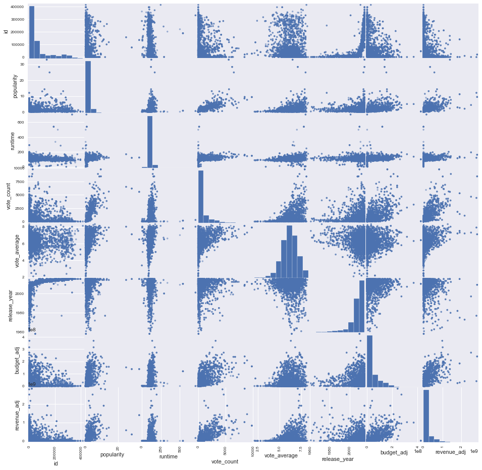

```python
# I'm going to look at the plots of all the variables to get an overview of how they're correlated and their dependencies.
pd.plotting.scatter_matrix(clean_movies, figsize = (16,16));
```

#### From the scatter matrix, it can be seen that there are several independant variables and several dependant variables. The independant variables are *runtime, budget_adj* and *id*. The dependant variables are *revenue_adj*.

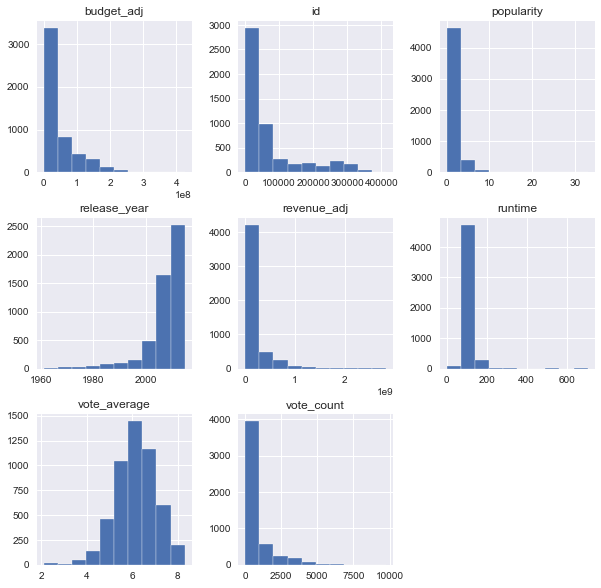

```python
clean_movies.hist(figsize=(10,10));
```

#### We can observe from the histograms of our data set, that the budget_adj, popularity, vote_count and runtime are all skewed to the right. Whereas release year and average vote are skewed to the left. These observatiosn indicate that only a small fraction of movies have high popularity, high budget and produce high revenues. It also shows that most of the movies in this dataset, were released after year 2000.

```python
#### Let's have a look at the budget histogram in more detail
```

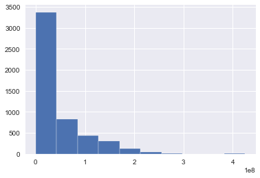

```python
clean_movies['budget_adj'].hist()
# We can see that the majority of movies have zero or low bugets, let's dig deeper into this.
```

```python
clean_movies['budget_adj'].describe()
```

```
count    5.123000e+03
mean     4.285440e+07
std      5.581630e+07
min      0.000000e+00
25%      8.243377e+01
50%      2.032801e+07
75%      6.310011e+07
max      4.250000e+08
Name: budget_adj, dtype: float64
```

### Research Question 1: Which movie genres are most popular from year to year?

```python
clean_movies['popularity'].describe()
```

```
count    5123.000000
mean        1.466109
std         2.092849
min         0.000620
25%         0.423160
50%         0.847636
75%         1.752987
max        32.985763
Name: popularity, dtype: float64
```

```python
genres_popularity = clean_movies.groupby(['release_year','genres']).agg({'popularity': ['mean']}, inplace=True)
genres_popularity.tail(25)
```

| release_year | genres | popularity mean |
| --- | --- | --- |
| 2014 | Romance | 1.024293 |
|  | Science Fiction | 4.536336 |
|  | TV Movie | 0.429625 |
|  | Thriller | 2.182128 |
|  | War | 2.809352 |
|  | Western | 0.384210 |
| 2015 | Action | 5.287050 |
|  | Adventure | 6.039085 |
|  | Animation | 2.366546 |
|  | Comedy | 1.831612 |
|  | Crime | 2.966320 |
|  | Documentary | 0.306533 |
|  | Drama | 1.804034 |
|  | Family | 2.468530 |
|  | Fantasy | 2.679600 |
|  | History | 1.065665 |
|  | Horror | 1.093884 |
|  | Music | 0.842710 |
|  | Mystery | 2.154227 |
|  | Romance | 1.595035 |
|  | Science Fiction | 4.984583 |
|  | TV Movie | 0.244950 |
|  | Thriller | 3.332036 |
|  | War | 2.347059 |
|  | Western | 7.504550 |

```python
genres_popularity = genres_popularity.reset_index()
genres_popularity.head()
```

[output not shown]

```python
genres_popularity.columns = genres_popularity.columns.get_level_values(0)
genres_popularity.head()
```

|  | index | release_year | genres | popularity |
| --- | --- | --- | --- | --- |
| 0 | 0 | 1961 | Comedy | 0.303783 |
| 1 | 1 | 1961 | Family | 0.303783 |
| 2 | 2 | 1962 | Action | 3.170651 |
| 3 | 3 | 1962 | Adventure | 3.170651 |
| 4 | 4 | 1962 | Thriller | 3.170651 |

```python
genres_popularity.describe()
```

|  | release_year | popularity |
| --- | --- | --- |
| count | 555.000000 | 555.000000 |
| mean | 1996.918919 | 1.544175 |
| std | 13.590939 | 1.261389 |
| min | 1961.000000 | 0.005529 |
| 25% | 1987.000000 | 0.800585 |
| 50% | 2000.000000 | 1.274139 |
| 75% | 2008.000000 | 1.902391 |
| max | 2015.000000 | 12.037933 |

```python
most_pop_genres = genres_popularity.query('popularity > 1.9')
most_pop_genres.sort_values(['release_year', 'popularity'], ascending = False, inplace = True)
most_pop_genres.head(20)
```

|  | index | release_year | genres | popularity |
| --- | --- | --- | --- | --- |
| 554 | 554 | 2015 | Western | 7.504550 |
| 537 | 537 | 2015 | Adventure | 6.039085 |
| 536 | 536 | 2015 | Action | 5.287050 |
| 550 | 550 | 2015 | Science Fiction | 4.984583 |
| 552 | 552 | 2015 | Thriller | 3.332036 |
| 540 | 540 | 2015 | Crime | 2.966320 |
| 544 | 544 | 2015 | Fantasy | 2.679600 |
| 543 | 543 | 2015 | Family | 2.468530 |
| 538 | 538 | 2015 | Animation | 2.366546 |
| 553 | 553 | 2015 | War | 2.347059 |
| 548 | 548 | 2015 | Mystery | 2.154227 |
| 518 | 518 | 2014 | Adventure | 5.052135 |
| 531 | 531 | 2014 | Science Fiction | 4.536336 |
| 517 | 517 | 2014 | Action | 3.469742 |
| 534 | 534 | 2014 | War | 2.809352 |
| 525 | 525 | 2014 | Fantasy | 2.789015 |
| 526 | 526 | 2014 | History | 2.531208 |
| 519 | 519 | 2014 | Animation | 2.359830 |
| 533 | 533 | 2014 | Thriller | 2.182128 |
| 512 | 512 | 2013 | Science Fiction | 2.787976 |

```python
pop_genres_2015 = most_pop_genres.query('release_year == 2015')
pop_genres_2014 = most_pop_genres.query('release_year == 2014')
pop_genres_2013 = most_pop_genres.query('release_year == 2013')
```

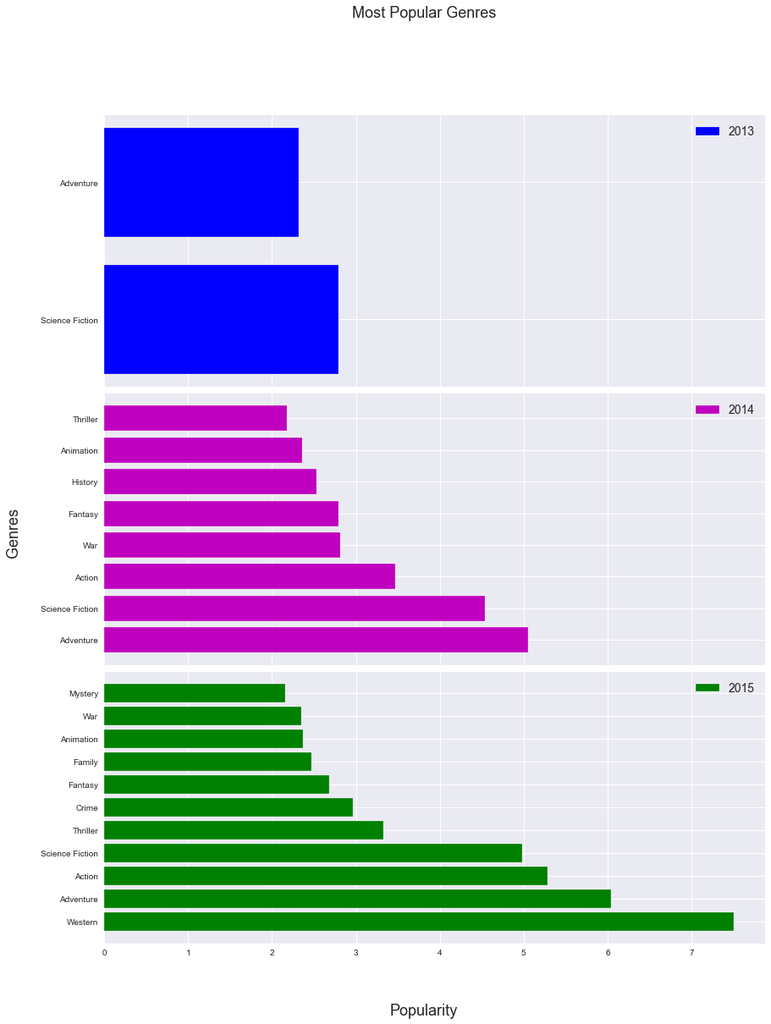

```python
fig, ax = plt.subplots(3, figsize = (14, 18), sharex = True)

ax[0].barh(pop_genres_2013['genres'], pop_genres_2013['popularity'], color = 'b')
ax[0].legend(['2013'], fontsize = 14)

ax[1].barh(pop_genres_2014['genres'], pop_genres_2014['popularity'], color = 'm')
ax[1].legend(['2014'], fontsize = 14)

ax[2].barh(pop_genres_2015['genres'], pop_genres_2015['popularity'], color = 'g')
ax[2].legend(['2015'], fontsize = 14)

fig.suptitle("Most Popular Genres", fontsize = 18)
fig.text(0.5, 0.06, 'Popularity', ha = 'center', fontsize = 18)
fig.text(0.01, 0.5,'Genres', va = 'center', rotation = 'vertical', fontsize = 18)
plt.subplots_adjust(wspace = 0.025, hspace = 0.025)

plt.show()
```

### Looking at the plots above, confirms our findings about the genres popularity YoY.

## Research Question 2: What are the 10 most popular movies between 1960 and 2015?

```python
# Let's see what's the popularity for the most famous 2% of movies?
clean_movies['popularity'].quantile(.98)
```

```
6.887883
```

```python
most_popular = clean_movies.query('popularity > 6.887')
most_popular_movies = most_popular.groupby(['original_title', 'popularity']).mean()
most_popular_movies.sort_values('popularity', ascending=False).head(10)
```

| original_title | popularity | id | runtime | vote_count | vote_average | release_year | budget_adj | revenue_adj |
| --- | --- | --- | --- | --- | --- | --- | --- | --- |
| Jurassic World | 32.985763 | 135397 | 124 | 5562 | 6.5 | 2015 | 1.379999e+08 | 1.392446e+09 |
| Mad Max: Fury Road | 28.419936 | 76341 | 120 | 6185 | 7.1 | 2015 | 1.379999e+08 | 3.481613e+08 |
| Interstellar | 24.949134 | 157336 | 169 | 6498 | 8.0 | 2014 | 1.519800e+08 | 5.726906e+08 |
| Guardians of the Galaxy | 14.311205 | 118340 | 121 | 5612 | 7.9 | 2014 | 1.565855e+08 | 7.122911e+08 |
| Insurgent | 13.112507 | 262500 | 119 | 2480 | 6.3 | 2015 | 1.012000e+08 | 2.716190e+08 |
| Captain America: The Winter Soldier | 12.971027 | 100402 | 136 | 3848 | 7.6 | 2014 | 1.565855e+08 | 6.583651e+08 |
| Star Wars | 12.037933 | 11 | 121 | 4428 | 7.9 | 1977 | 3.957559e+07 | 2.789712e+09 |
| John Wick | 11.422751 | 245891 | 101 | 2712 | 7.0 | 2014 | 1.842182e+07 | 7.252661e+07 |
| Star Wars: The Force Awakens | 11.173104 | 140607 | 136 | 5292 | 7.5 | 2015 | 1.839999e+08 | 1.902723e+09 |
| The Hunger Games: Mockingjay - Part 1 | 10.739009 | 131631 | 123 | 3590 | 6.6 | 2014 | 1.151364e+08 | 6.927528e+08 |

### The 10 most popular movies between 1960 and 2015 are: *'Jurassic World', 'Mad Max: Fury Road', 'Interstellar', 'Guardians of the Galaxy', 'Insurgent', 'Captain America: The Winter Soldier', 'Star Wars', 'John Wick', 'Star Wars: The Force Awakens' and 'The Hunger Games: Mockingjay - Part 1'*.

### Research Question 3: What kinds of properties are associated with movies that have high revenues?

```python
# Let's investigate the adjusted revenue column first:
clean_movies['revenue_adj'].describe()
```

```
count    5.123000e+03
mean     1.524784e+08
std      2.806311e+08
min      0.000000e+00
25%      0.000000e+00
50%      3.564366e+07
75%      1.735719e+08
max      2.827124e+09
Name: revenue_adj, dtype: float64
```

```python
# We will devide the revenue_adj column into categories. Bin edges that will be used to cut the data into groups are:
bin_edges = [0, 3.56e+07, 1.74e+08, 2.83e+09]
# Labels for the four acidity level groups
bin_names = ['low', 'medium', 'high']
```

```python
clean_movies['revenue_adj_levels'] = pd.cut(clean_movies['revenue_adj'], bin_edges, labels = bin_names)
clean_movies.head()
```

|  | id | popularity | original_title | cast | director | runtime | genres | production_companies | vote_count | vote_average | release_year | budget_adj | revenue_adj | revenue_adj_levels |
| --- | --- | --- | --- | --- | --- | --- | --- | --- | --- | --- | --- | --- | --- | --- |
| 0 | 135397 | 32.985763 | Jurassic World | Chris Pratt\|Bryce Dallas Howard\|Irrfan Khan\|Vi... | Colin Trevorrow | 124 | Action | Universal Studios\|Amblin Entertainment\|Legenda... | 5562 | 6.5 | 2015 | 1.379999e+08 | 1.392446e+09 | high |
| 1 | 135397 | 32.985763 | Jurassic World | Chris Pratt\|Bryce Dallas Howard\|Irrfan Khan\|Vi... | Colin Trevorrow | 124 | Adventure | Universal Studios\|Amblin Entertainment\|Legenda... | 5562 | 6.5 | 2015 | 1.379999e+08 | 1.392446e+09 | high |
| 2 | 135397 | 32.985763 | Jurassic World | Chris Pratt\|Bryce Dallas Howard\|Irrfan Khan\|Vi... | Colin Trevorrow | 124 | Science Fiction | Universal Studios\|Amblin Entertainment\|Legenda... | 5562 | 6.5 | 2015 | 1.379999e+08 | 1.392446e+09 | high |
| 3 | 135397 | 32.985763 | Jurassic World | Chris Pratt\|Bryce Dallas Howard\|Irrfan Khan\|Vi... | Colin Trevorrow | 124 | Thriller | Universal Studios\|Amblin Entertainment\|Legenda... | 5562 | 6.5 | 2015 | 1.379999e+08 | 1.392446e+09 | high |
| 4 | 76341 | 28.419936 | Mad Max: Fury Road | Tom Hardy\|Charlize Theron\|Hugh Keays-Byrne\|Nic... | George Miller | 120 | Action | Village Roadshow Pictures\|Kennedy Miller Produ... | 6185 | 7.1 | 2015 | 1.379999e+08 | 3.481613e+08 | high |

```python
high_revenue_df = clean_movies.query('revenue_adj_levels == "high"')
high_revenue_df.head()
```

[output not shown]

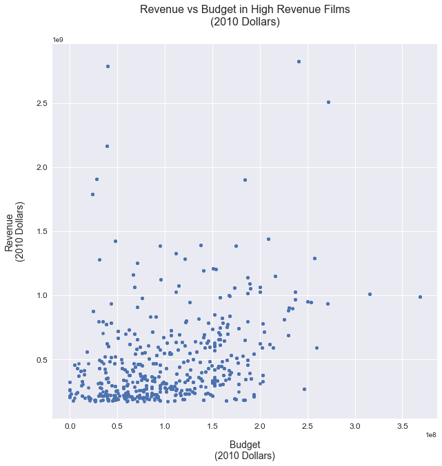

```python
high_revenue_df.plot(x='budget_adj', y='revenue_adj', kind='scatter', figsize=(10,10));
plt.xlabel("Budget\n(2010 Dollars)", fontsize=14, labelpad=15)
plt.ylabel("Revenue\n(2010 Dollars)", fontsize=14, labelpad=15)
plt.title('Revenue vs Budget in High Revenue Films\n(2010 Dollars)', fontsize=16, y=1.04)
plt.tick_params(labelsize=12)
```

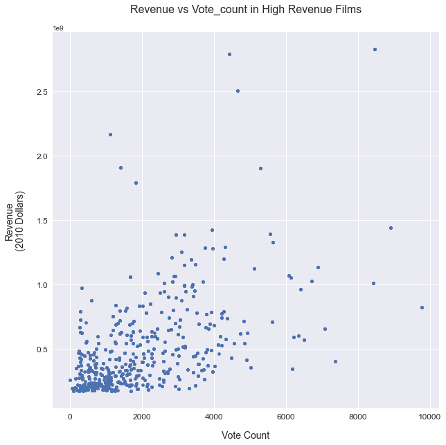

```python
high_revenue_df.plot(x='vote_count', y='revenue_adj', kind='scatter', figsize=(10,10))
plt.xlabel("Vote Count", fontsize=14, labelpad=15)
plt.ylabel("Revenue\n(2010 Dollars)", fontsize=14, labelpad=15)
plt.title('Revenue vs Vote_count in High Revenue Films', fontsize=16, y=1.04)
plt.tick_params(labelsize=12);
```

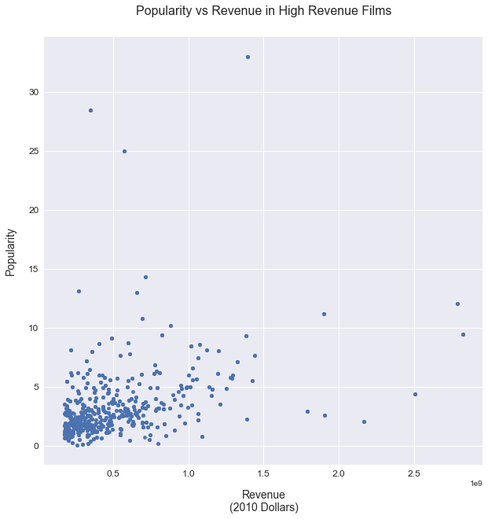

```python
high_revenue_df.plot(x='revenue_adj', y='popularity', kind='scatter', figsize=(10,10));
plt.title('Popularity vs Revenue in High Revenue Films', fontsize=16, y=1.04)
plt.xlabel("Revenue\n(2010 Dollars)", fontsize=14, labelpad=15)
plt.ylabel("Popularity", fontsize=14, labelpad=15)
plt.tick_params(labelsize=12)
```

### Research Question 4: How have the anuual profitability of the movies changed over time?

```python
# Let's calculate the adjusted profitability,(in 2010 dollars) for our dataset.
clean_movies.insert(14,'profit_adj', clean_movies['revenue_adj']-clean_movies['budget_adj'])
```

```python
clean_movies.head(2)
```

|  | id | popularity | original_title | cast | director | runtime | genres | production_companies | vote_count | vote_average | release_year | budget_adj | revenue_adj | revenue_adj_levels | profit_adj |
| --- | --- | --- | --- | --- | --- | --- | --- | --- | --- | --- | --- | --- | --- | --- | --- |
| 0 | 135397 | 32.985763 | Jurassic World | Chris Pratt\|Bryce Dallas Howard\|Irrfan Khan\|Vi... | Colin Trevorrow | 124 | Action | Universal Studios\|Amblin Entertainment\|Legenda... | 5562 | 6.5 | 2015 | 1.379999e+08 | 1.392446e+09 | high | 1.254446e+09 |
| 1 | 135397 | 32.985763 | Jurassic World | Chris Pratt\|Bryce Dallas Howard\|Irrfan Khan\|Vi... | Colin Trevorrow | 124 | Adventure | Universal Studios\|Amblin Entertainment\|Legenda... | 5562 | 6.5 | 2015 | 1.379999e+08 | 1.392446e+09 | high | 1.254446e+09 |

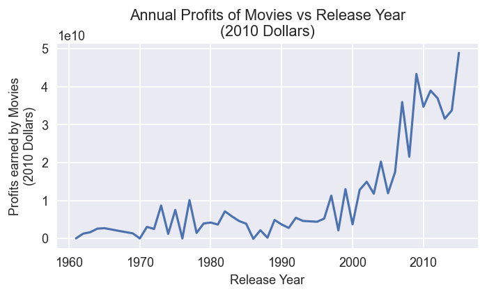

```python
annual_profits_total = clean_movies.groupby('release_year')['profit_adj'].sum()

plt.figure(figsize=(6,3), dpi = 130)
# x-axis
plt.xlabel('Release Year', fontsize = 10)
# y-axis
plt.ylabel('Profits earned by Movies\n(2010 Dollars)', fontsize = 10)
#title of the line plot
plt.title('Annual Profits of Movies vs Release Year\n(2010 Dollars)')

#plotting the graph
plt.plot(annual_profits_total)

#displaying the line plot
plt.show()
```

### The plot shows that the annular profits by movies were in somewhat of a flat trend from the 1960s to the year 2000. Starting year 2000, we can see an exponential increase in the profitability of the movies. Let's investigate whether the budget can be a contributing factor in this uptrend.

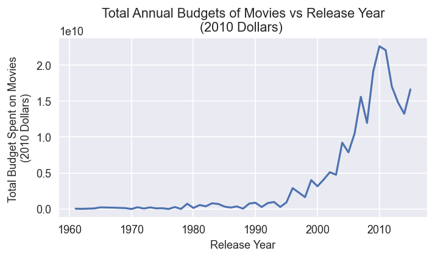

```python
annual_budget_total = clean_movies.groupby('release_year')['budget_adj'].sum()

plt.figure(figsize=(6,3), dpi = 130)
# x-axis
plt.xlabel('Release Year', fontsize = 10)
# y-axis
plt.ylabel('Total Budget Spent on Movies \n(2010 Dollars)', fontsize = 10)
#title of the line plot
plt.title('Total Annual Budgets of Movies vs Release Year\n(2010 Dollars) ')

#plotting the graph
plt.plot(annual_budget_total)

#displaying the line plot
plt.show()
```

### We can see that the budget spent on the movies follows the same trend as the annual profits.

### Research Question 5: What is the average money made by each movie?

```python
average_revenue = clean_movies['profit_adj'].unique().mean()
average_revenue
```

```
118124726.23480198
```

### Research Question 6: Have the movies become shorter or longer over the years?

```python
clean_movies['runtime'].describe()
```

```
count    5123.000000
mean      106.454031
std        30.644126
min         0.000000
25%        93.000000
50%       102.000000
75%       116.000000
max       705.000000
Name: runtime, dtype: float64
```

```python
# Looks like more than half of the movies have a duration between 90-120 minutes. Now let's look at the yearly fluctuations in movie duration.
```

```python
anual_average_movie_runtime = clean_movies.groupby('release_year')['runtime'].mean()
anual_average_movie_runtime.tail(10)
```

```
release_year
2006    110.761134
2007    106.108033
2008    101.211111
2009    103.692623
2010    106.930636
2011    104.406367
2012    101.626667
2013    104.549080
2014    105.807263
2015    105.843373
Name: runtime, dtype: float64
```

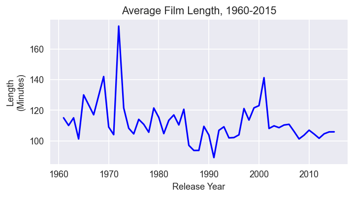

```python
# Now we can take a look at the diagram of runtimes over the years to see if there's a pattern.
plt.figure(figsize=(6,3), dpi = 130)
# x-axis
plt.xlabel('Release Year', fontsize = 10)
# y-axis
plt.ylabel('Length\n(Minutes)', fontsize = 10)
#title of the line plot
plt.title('Average Film Length, 1960-2015')

#plotting the graph
plt.plot(anual_average_movie_runtime, color = 'b')

#displaying the line plot
plt.show()
```

### Overal, movie duration is not in an upward or downward trend. The chart shows that for majority of the years analyzed, the movie duration have been rangebound between 90-120 minutes.

## Conclusions

### - The movie duration has been rangebound between 90-120 minutes with no specific trend year over year.

### Restrictions to the dataset:

### There are very few movies ~25% released between 1960 to 1995 so the majority of the movies analyzed here, were released after year 1995. Also, there is zero budget or revenue reported for at least half of the movies. I am guessing that these movies might be independent films shot with little to no funding from a major film studio or a private investor.